# Drilling down into fire modeling absolute metrics

SIG

2024-02-08

## Fire modeling absolute metrics exploration example

The full dataset includes multiple outcome metrics for 27 scenarios (with different grouping factors, such as treatment priority, intensity, type) at four different time points (Year 0, 5, 10, 20). There are a great number of variations and combinations that the data can be summarized and visualized.

First, we will import the R library packages that we will need.

```r
### Libraries -------------------------------------------------
if (!require("pacman")) install.packages("pacman")
pacman::p_load(
  tidyverse)
```

In this example, we will pick Year 20 to explore, and will filter the dataset to only Year 2044. The weather in the fire modeling is based on current weather for 2024 and 2029 timesteps, but includes future weather predictions for 2034 and 2044. Whenever you are doing cross-years comparisons, you should remember that there are also weather effects in play. For now we will focus on a single year.

```r
### Data import -------------------------------------------

res_orig <- read_csv(file.path('..', '..', 'results_csv',
                          'datacube_weighted_20240205.csv')) %>%
  mutate(HUC12 = as.character(HUC12))
```

```r
#Setting a factor order so that graphs show in this order
# Want priority order: 'Fire', 'WUI', 'Hybrid'
# Want intensity order: '500k', '1m', '2m'

res <- res_orig %>%
  #For graphing in the correct order
  # make factor with set order (priority)
  mutate(Priority = as.factor(Priority),
         Priority = forcats::fct_relevel(Priority,
                                         "Fire", "WUI", "Hybrid"),
         #Make factor with set order (intensity))
         TxIntensity = as.factor(TxIntensity),
         TxIntensity = forcats::fct_relevel(TxIntensity,
                                            "500k", "1m", "2m"))

#Year 20
res2044 <- res %>%
  filter(Year == 2044)
```

Suppose we are interested in comparing the difference between the different intensity scenarios (500k, 1m, and 2m). We can filter our dataset three times, once for each intensity group. We rename the outcome metrics to reflect what intensity the scenario was.

```r
res2044_500k <- res2044 %>%
  filter(TxIntensity == "500k") %>%
  rename(expBurn_500k = expBurn,
         expFlame_500k = expFlame,
         expAcf_500k = expPcActive)

res2044_1m <- res2044 %>%
  filter(TxIntensity == "1m") %>%
  rename(expBurn_1m = expBurn,
         expFlame_1m = expFlame,
         expAcf_1m = expPcActive)

res2044_2m <- res2044 %>%
  filter(TxIntensity == "2m") %>%
  rename(expBurn_2m = expBurn,
         expFlame_2m = expFlame,
         expAcf_2m = expPcActive)
```

Then we will join our different intensity tables with each other, careful to match on HUC and all other scenario-defining variables. We want to make sure we are comparing e.g. `HUC A - Fire Priority - trt1 type - 2.3 m` to `HUC A - Fire Priority - trt1 type - 500k` (i.e. only the intensity is different).

```r
res2044_jt <- res2044_500k %>%
  left_join(res2044_1m, by = join_by(HUC12, Region, Priority, TxType)) %>%
  left_join(res2044_2m, by = join_by(HUC12, Region, Priority, TxType))


#selecting only the relevant fields for convenience
res2044_trim <- res2044_jt %>%
  dplyr::select(HUC12, Region, Priority, TxType,
         expBurn_500k, expBurn_2m,
         expFlame_500k, expFlame_2m,
         expAcf_500k, expAcf_2m)
```

Now suppose we are interested in comparing the 500k intensity and 2.3 million intensity. We can plot a joint distribution plot (scatter plot) of the 500k expected burned acres against the 2.3 million intensity expected burned acres. We can also do the same for other metrics, such as the expected total flame length.

The x-axis is the expBurn value of the 500k intensity (baseline) for each HUC-priority-type combination, and the y-axis would be the expBurn for the matching HUC-priority-type combination for the 2.3 million intensity level. Adding a 1:1 relationship line visually shows where the expBurn values are equal (i.e. the treatment intensity change did not have an effect). Adding a trend line (linear regression) of the observed expBurn values would show if the increase in intensity caused a change in expBurn values - when the slope of the trend line is less than the 1:1 relationship, the increase in intensity caused a decrease in expBurn.

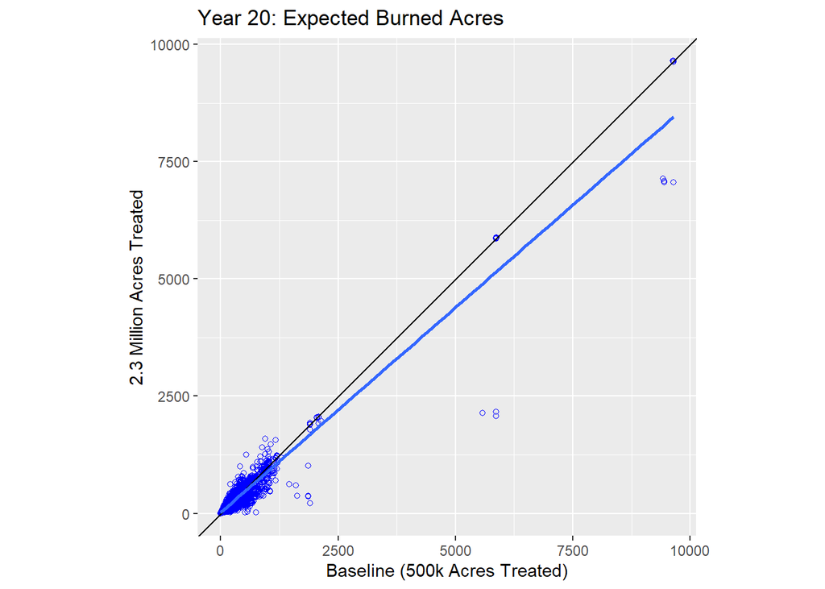

```r
#overall expBurn
plot_yr20_expBurn_overall <- ggplot() +
  geom_point(data=res2044_trim,
             aes(x=expBurn_500k, y=expBurn_2m),
             shape=1, color="blue") +
  theme(aspect.ratio = 1) +
  geom_abline(intercept=0, slope=1) +
  stat_smooth(data=res2044_trim,
              aes(x=expBurn_500k, y=expBurn_2m),
              method=lm,
              geom="smooth",
              formula = 'y ~ x',
              se = FALSE,
              fullrange = TRUE) +
  labs(title="Year 20: Expected Burned Acres",
       x="Baseline (500k Acres Treated)",
       y="2.3 Million Acres Treated")
plot_yr20_expBurn_overall
```

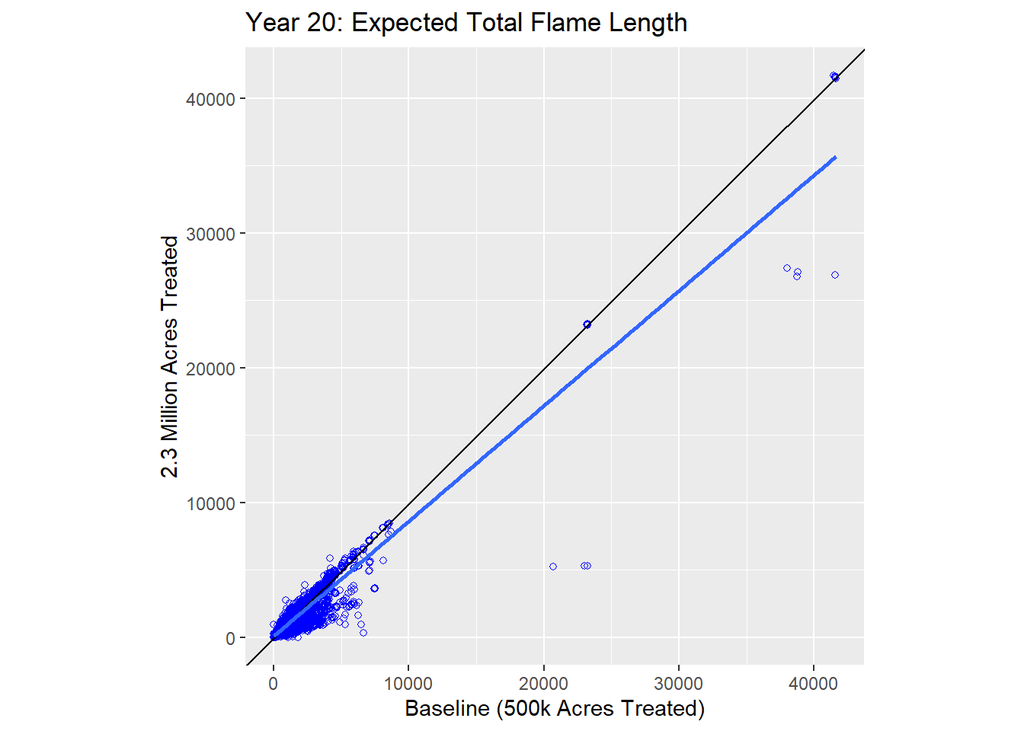

```r
#overall expFlame
plot_yr20_expFlame_overall <- ggplot() +
  geom_point(data=res2044_trim,
             aes(x=expFlame_500k, y=expFlame_2m),
             shape=1, color="blue") +
  theme(aspect.ratio = 1) +
  geom_abline(intercept=0, slope=1) +
  stat_smooth(data=res2044_trim,
              aes(x=expFlame_500k, y=expFlame_2m),
              method=lm,
              geom="smooth",
              formula = 'y ~ x',
              se = FALSE,
              fullrange = TRUE) +
  labs(title="Year 20: Expected Total Flame Length",
       x="Baseline (500k Acres Treated)",
       y="2.3 Million Acres Treated")
plot_yr20_expFlame_overall
```

We see that in year 20, increasing the intensity does reduce expBurn and expFlame overall (the blue trend line slope is less than the black 1:1 relationship line).

There are many factors that we would like to consider, and we can begin to separate out plots to look at different aspects. The above plot includes all regions, all priorities, and all treatment types.

For example, this is the same expBurn and expFlame plots as above, but faceted (grouped and separated) by region.

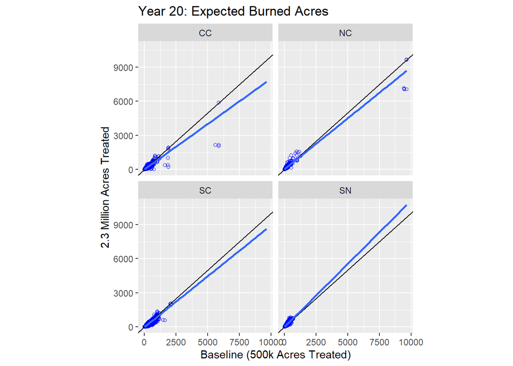

```r
#region
plot_yr20_expBurn_reg <- ggplot() +
  geom_point(data=res2044_trim,
             aes(x=expBurn_500k, y=expBurn_2m),
             shape=1, color="blue") +
  theme(aspect.ratio = 1) +
  geom_abline(intercept=0, slope=1) +
  stat_smooth(data=res2044_trim,
              aes(x=expBurn_500k, y=expBurn_2m),
              method=lm,
              geom="smooth",
              formula = 'y ~ x',
              se = FALSE,
              fullrange = TRUE) +
  labs(title="Year 20: Expected Burned Acres",
       x="Baseline (500k Acres Treated)",
       y="2.3 Million Acres Treated") +
  facet_wrap(~Region)
plot_yr20_expBurn_reg
```

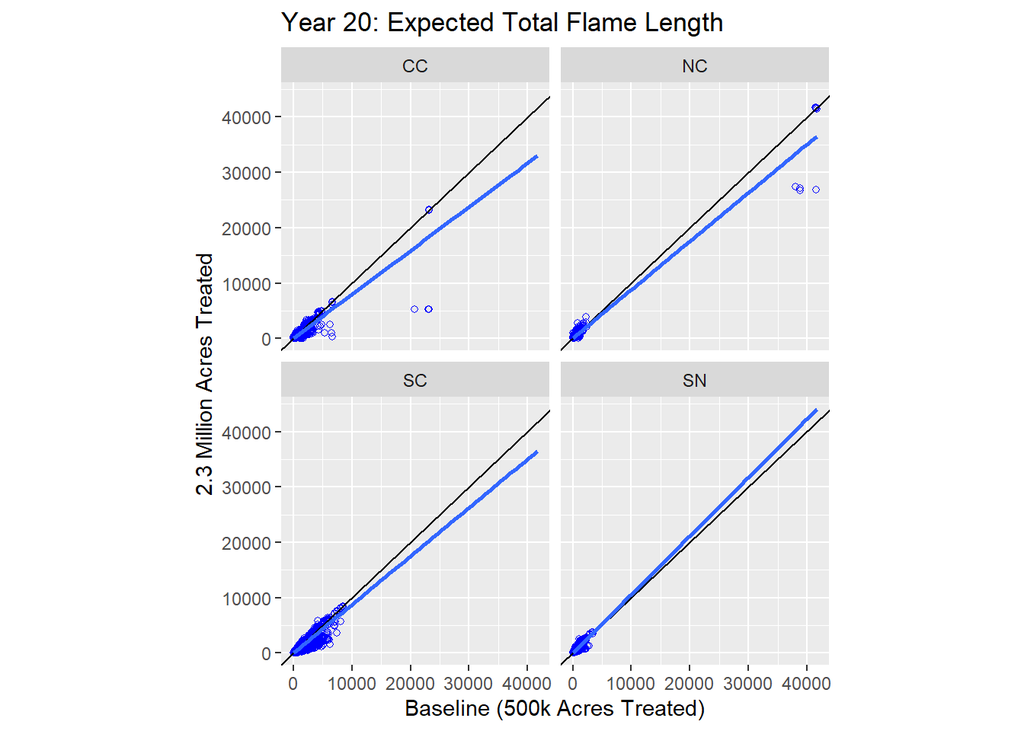

```r
plot_yr20_expFlame_reg <- ggplot() +
  geom_point(data=res2044_trim,
             aes(x=expFlame_500k, y=expFlame_2m),
             shape=1, color="blue") +
  theme(aspect.ratio = 1) +
  geom_abline(intercept=0, slope=1) +
  stat_smooth(data=res2044_trim,
              aes(x=expFlame_500k, y=expFlame_2m),
              method=lm,
              geom="smooth",
              formula = 'y ~ x',
              se = FALSE,
              fullrange = TRUE) +
  labs(title="Year 20: Expected Total Flame Length",
       x="Baseline (500k Acres Treated)",
       y="2.3 Million Acres Treated") +
  facet_wrap(~Region)
plot_yr20_expFlame_reg
```

Or we could look at priority and treatment type.

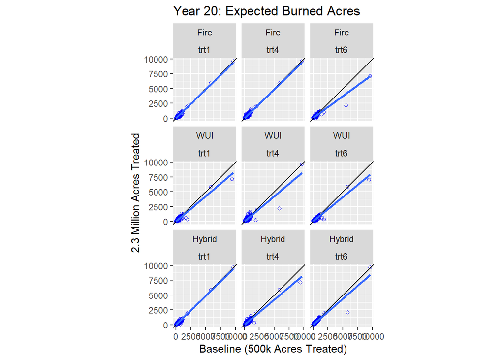

```r
plot_yr20_expBurn_pt <- ggplot() +
  geom_point(data=res2044_trim,
             aes(x=expBurn_500k, y=expBurn_2m),
             shape=1, color="blue") +
  theme(aspect.ratio = 1) +
  geom_abline(intercept=0, slope=1) +
  stat_smooth(data=res2044_trim,
              aes(x=expBurn_500k, y=expBurn_2m),
              method=lm,
              geom="smooth",
              formula = 'y ~ x',
              se = FALSE,
              fullrange = TRUE) +
  labs(title="Year 20: Expected Burned Acres",
       x="Baseline (500k Acres Treated)",
       y="2.3 Million Acres Treated") +
  facet_wrap(~Priority+TxType)
plot_yr20_expBurn_pt
```

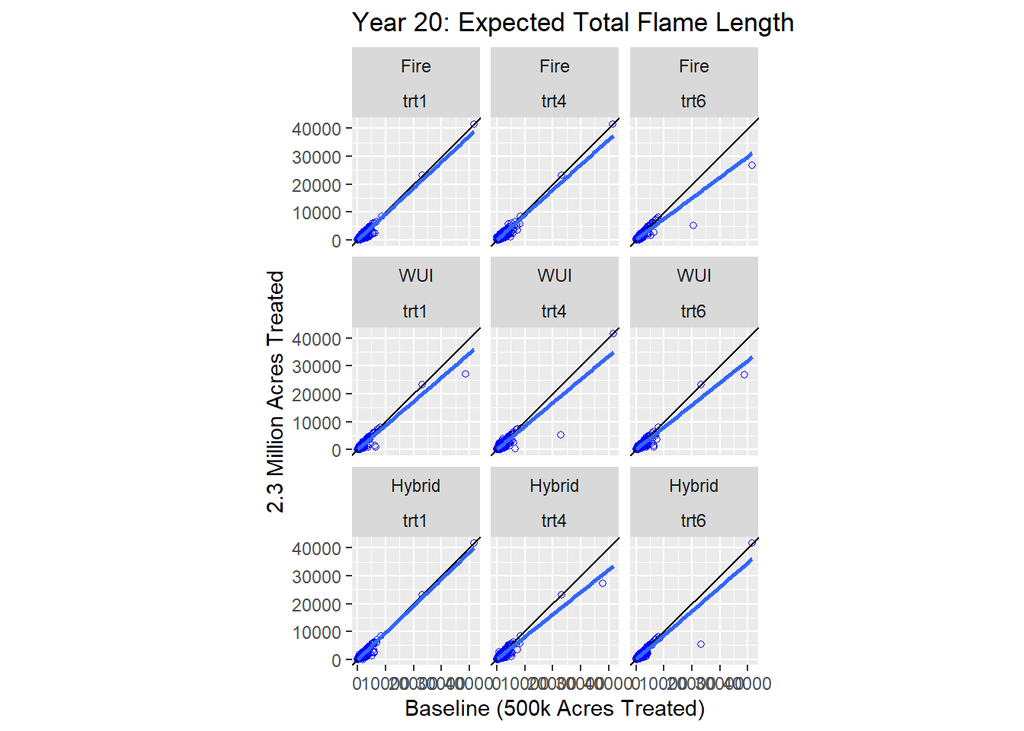

```r
plot_yr20_expFlame_pt <- ggplot() +
  geom_point(data=res2044_trim,
             aes(x=expFlame_500k, y=expFlame_2m),
             shape=1, color="blue") +
  theme(aspect.ratio = 1) +
  geom_abline(intercept=0, slope=1) +
  stat_smooth(data=res2044_trim,
              aes(x=expFlame_500k, y=expFlame_2m),
              method=lm,
              geom="smooth",
              formula = 'y ~ x',
              se = FALSE,
              fullrange = TRUE) +
  labs(title="Year 20: Expected Total Flame Length",
       x="Baseline (500k Acres Treated)",
       y="2.3 Million Acres Treated") +
  facet_wrap(~Priority+TxType)
plot_yr20_expFlame_pt
```

### SC Region

We could want to only look at one region at a time, so we can add another filtering step.

```r
#SC only
res2044sc <- res2044_trim %>%
  filter(Region == "SC")
```

And then we can repeat our graphing, perhaps for both priority and treatment type.

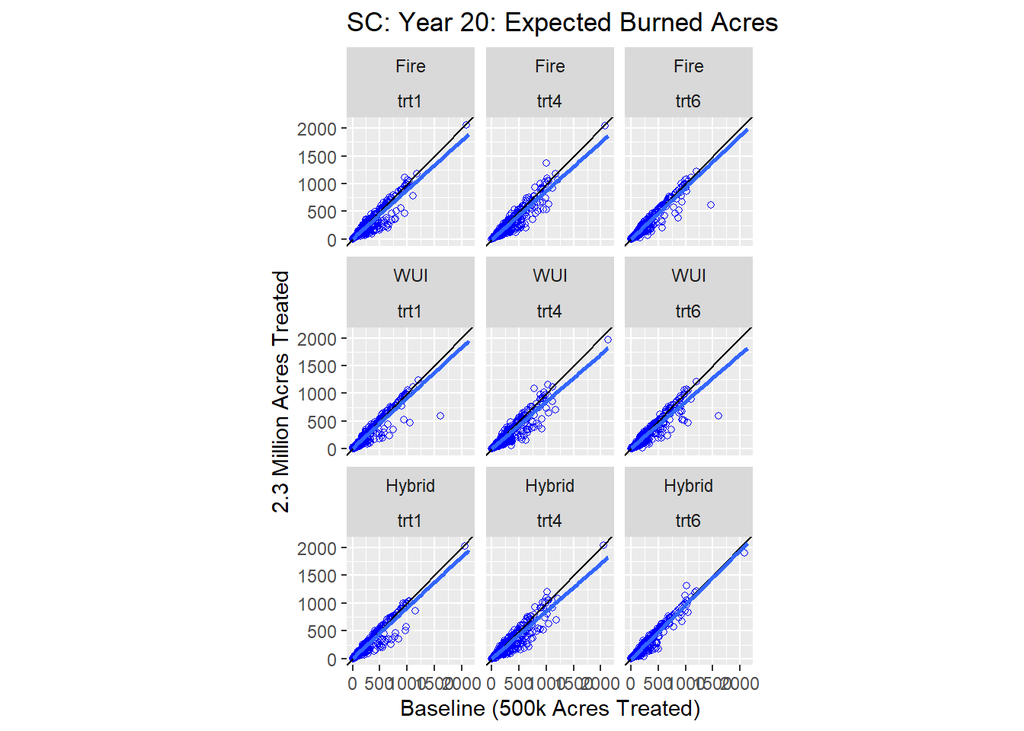

```r
plot_yr20_sc_expBurn_pt <- ggplot() +
  geom_point(data=res2044sc,
             aes(x=expBurn_500k, y=expBurn_2m),
             shape=1, color="blue") +
  theme(aspect.ratio = 1) +
  geom_abline(intercept=0, slope=1) +
  stat_smooth(data=res2044sc,
              aes(x=expBurn_500k, y=expBurn_2m),
              method=lm,
              geom="smooth",
              formula = 'y ~ x',
              se = FALSE,
              fullrange = TRUE) +
  labs(title="SC: Year 20: Expected Burned Acres",
       x="Baseline (500k Acres Treated)",
       y="2.3 Million Acres Treated") +
  facet_wrap(~Priority+TxType)
plot_yr20_sc_expBurn_pt
```

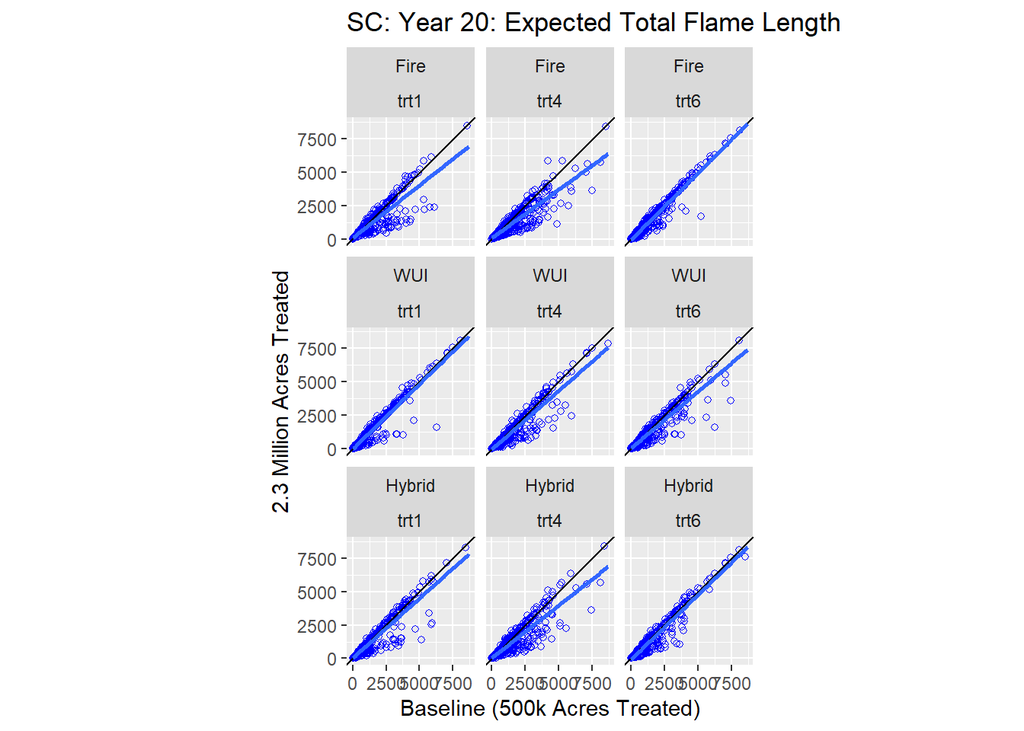

```r
plot_yr20_sc_expFlame_pt <- ggplot() +
  geom_point(data=res2044sc,
             aes(x=expFlame_500k, y=expFlame_2m),
             shape=1, color="blue") +
  theme(aspect.ratio = 1) +
  geom_abline(intercept=0, slope=1) +
  stat_smooth(data=res2044sc,
              aes(x=expFlame_500k, y=expFlame_2m),
              method=lm,
              geom="smooth",
              formula = 'y ~ x',
              se = FALSE,
              fullrange = TRUE) +
  labs(title="SC: Year 20: Expected Total Flame Length",
       x="Baseline (500k Acres Treated)",
       y="2.3 Million Acres Treated") +
  facet_wrap(~Priority+TxType)
plot_yr20_sc_expFlame_pt
```

#### Boxplots

Joint distribution plots are convenient for comparing two aspects against each other, but we can also graph some of the same information in different ways. To avoid too cluttered of charts, we may need to partition the dataset in some fashion (filtering or faceting).

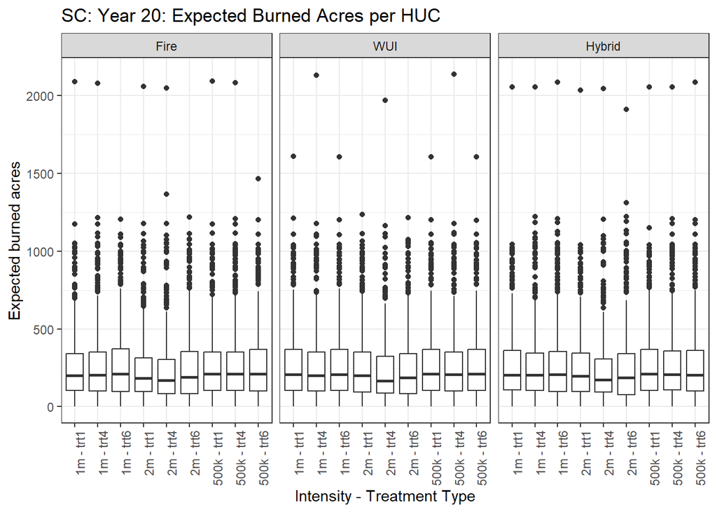

```r
# Returning to original 2044 dataset
r44sc <- res2044 %>%
  filter(Region == "SC") %>%
  # Need a single field for labeling scenario
  mutate(scenario = paste0(Priority, " - ",
                           TxIntensity, " - ",
                           TxType),
         scenario_intensity_type = paste0(TxIntensity, " - ", TxType))

ggplot() +
  geom_boxplot(data=r44sc,
               mapping=aes(x=scenario_intensity_type, y=expBurn)) +
    labs(title="SC: Year 20: Expected Burned Acres per HUC",
       x="Intensity - Treatment Type",
       y="Expected burned acres") +
  theme_bw() +
  theme(axis.text.x = element_text(angle = 90, vjust = 1, hjust=1)) +
  facet_wrap(~Priority)
```

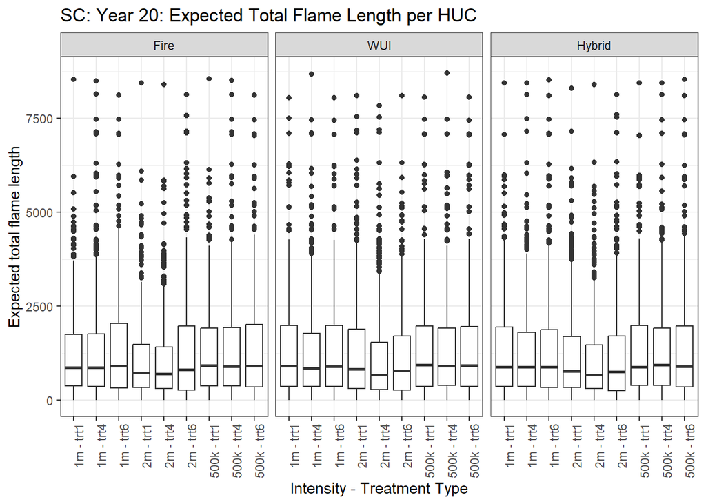

```r
ggplot() +
  geom_boxplot(data=r44sc,
               mapping=aes(x=scenario_intensity_type, y=expFlame)) +
    labs(title="SC: Year 20: Expected Total Flame Length per HUC",
       x="Intensity - Treatment Type",
       y="Expected total flame length") +
  theme_bw() +
  theme(axis.text.x = element_text(angle = 90, vjust = 1, hjust=1)) +
  facet_wrap(~Priority)
```

Instead of individual HUC points, we may wish to add all burned area together, region-wide.

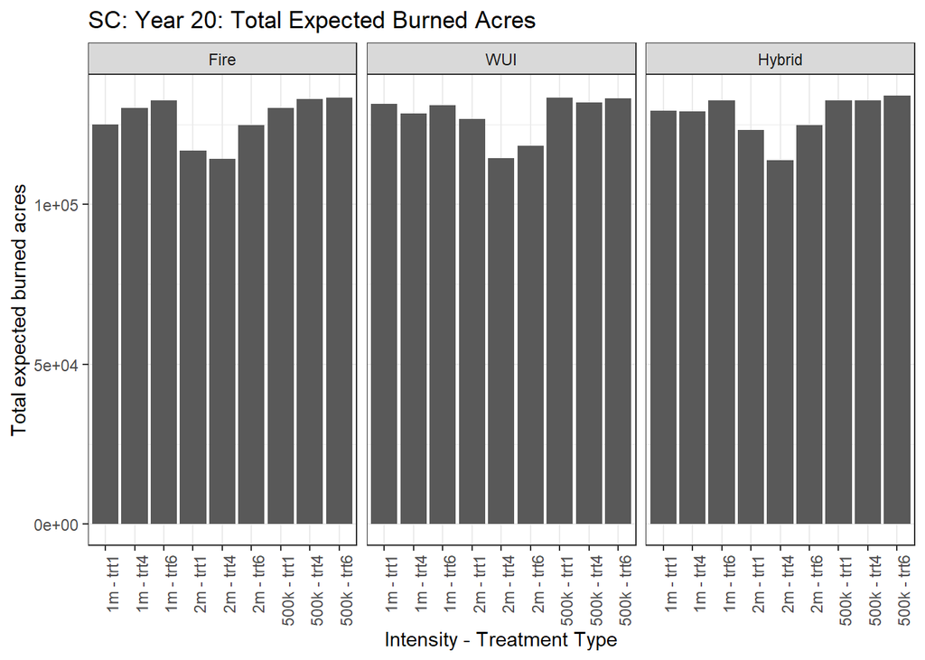

```r
r44sc_summarized <- r44sc %>%
  group_by(Priority, TxIntensity, TxType) %>%
  summarize(sum_expBurn = sum(expBurn),
            .groups="drop") %>%
  mutate(intensity_type = paste0(TxIntensity, " - ", TxType),
         priority_intensity = paste0(Priority, " - ", TxIntensity))

ggplot() +
  geom_col(data=r44sc_summarized,
               mapping=aes(x=intensity_type, y=sum_expBurn)) +
    labs(title="SC: Year 20: Total Expected Burned Acres",
       x="Intensity - Treatment Type",
       y="Total expected burned acres") +
  theme_bw() +
  theme(axis.text.x = element_text(angle = 90, vjust = 1, hjust=1)) +
  facet_wrap(~Priority)
```

Or reworking the summarizing and faceting, here’s another way to view the same information.

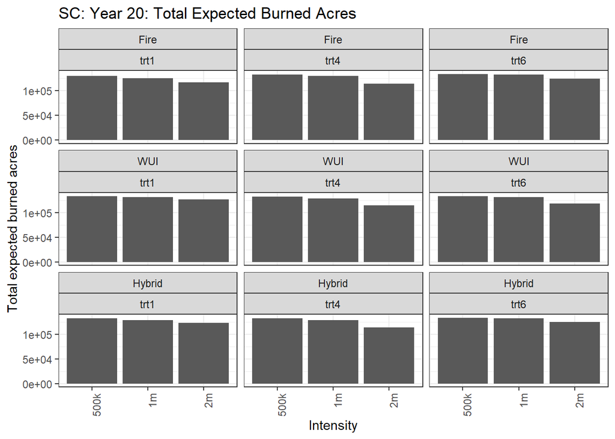

```r
r44sc_sum2 <- r44sc %>%
  group_by(Priority, TxIntensity, TxType) %>%
  summarize(sum_expBurn = sum(expBurn),
            .groups="drop")

ggplot() +
  geom_col(data=r44sc_sum2,
               mapping=aes(x=TxIntensity, y=sum_expBurn)) +
    labs(title="SC: Year 20: Total Expected Burned Acres",
       x="Intensity",
       y="Total expected burned acres") +
  theme_bw() +
  theme(axis.text.x = element_text(angle = 90, vjust = 1, hjust=1)) +
  facet_wrap(~Priority+TxType)
```

### Future analyses

With four regions, three scenario variables with three levels each, and several outcome metrics, there are a multitude of combinations that could be compared and graphed, depending on the question you wish to answer.

Note on between year comparisons: As weather also changes in Year 10 and Year 20, comparing across years will include effects from treatments and weather (which may be opposing effects) and should be kept in consideration when interpreting results.